## Dacade Means

For the SST data loaded using the code below: Generate a data frame with the Empirical Spatial Means per decade (1970-1979, 1980-1989, 1990-2002) and plot them with one panel per decade

```r
# summary(SST_df)
SST_df <- SST_df %>% filter(!is.na(Year),!is.na(sst))
SST_df$decade <- cut(SST_df$Year, # bin the year into
                         c(1970,1980,1990,2002), # their respective bins
                         labels = c("70s","80s","90s-2002"), # assign labels
                         include.lowest = T) # include edges,right=F
summ <- SST_df %>% group_by(decade) %>% summarise(decade_means=mean(sst))
# year-year%%10 # floor_date(date,unit = 'year') # floor(decimal_date(date)/10)*10
head(summ)
```

[output not shown]

```r
SST_df %>% group_by(lon,lat,decade) %>% summarise(z=mean(sst)) %>%
  ggplot() +
  geom_point(aes(x=lon,y=lat,colour=z),size=1) +
  col_scale(name = "mean_sst") +
  xlab("Longitude (deg)") + ylab("Latitude (deg)") +
  geom_path(data = map_data("world"),# world boundaries
            aes(x = long, y = lat, group = group)) +
  coord_fixed(xlim = c(124, 290),ylim= c(-29,29)) +
  facet_wrap(.~decade,nrow=3)+
  theme_bw()
```

[output not shown]

## yearly 95th quantile

generate a spatial plot for the **yearly** SST 95th quantile for the years 1980, 1990, 2000 having one panel per year

```r
SST_df %>% filter(Year%in%c(1980,1990,2000)) %>%
  group_by(lon,lat,Year) %>% summarise(z=quantile(sst,.95)) %>%
  ggplot() +
  geom_point(aes(x=lon,y=lat,colour=z),size=1) +
  col_scale(name = ".95q_sst") +
  xlab("Longitude (deg)") + ylab("Latitude (deg)") +
  geom_path(data = map_data("world"),# world boundaries
            aes(x = long, y = lat, group = group)) +
  coord_fixed(xlim = c(124, 290),ylim= c(-29,29)) +
  facet_wrap(.~Year,nrow=3)+
  theme_bw()
```

[output not shown]

## Hovmoller plot

Obtain a Hovmoller plot for these data

```r
lim_lat <- range(SST_df$lat)  # latitude range
lim_t <- range(SST_df$Year) # time range
lat_axis <- seq(lim_lat[1], lim_lat[2],length=59) # latitude axis
t_axis <- seq(lim_t[1], lim_t[2],length=33)# time axis
lat_t_grid <- expand.grid(lat = lat_axis, t = t_axis)
```

```r
SST_grid <- SST_df
dists <- abs(outer(SST_df$lat, lat_axis, "-"))
SST_grid$lat <- lat_axis[apply(dists, 1, which.min)]
```

```r
SST_lat_Hov <- SST_grid %>% group_by(lat, Year) %>%
summarise(z = mean(sst))
```

```r
ggplot(SST_lat_Hov) +
  geom_tile(aes(x = lat, y = Year, fill = z)) +
  fill_scale(name = "mean_sst") + scale_y_reverse() +
  ylab("Years") + xlab("Latitude (degrees)") +
  theme_bw()
```

[output not shown]

## EOFs

Calculate the EOFs for the *SST* dataset. Replicate the figures in pages 44-45 using the R function `eigen` (not `svd`) and `ggplot2::geom\_tile` and interpret them. How many EOFs would you retain?

```r
Z <- t(SSTdata) # dim(Z)
spat_mean <- apply(SSTdata, 1, mean)
nT <- ncol(SSTdata)
nS <- nrow(SSTdata)
Zspat_detrend <- Z - outer(rep(1, nT), spat_mean) #subtract and standardize:
Zt <- 1/sqrt(nT - 1)*Zspat_detrend # dim(Zt)
```

```r
ATA <- eigen(t(Zt)%*%Zt,symmetric=T)
V <- ATA$vectors[,1:nT]
AAT <- eigen(Zt%*%t(Zt),symmetric=T)
U <- AAT$vectors
D <- diag(sqrt(AAT$values))
```

```r
round(E$v[1:5,1:8],4)
```

```
        [,1]    [,2]    [,3]   [,4]   [,5]    [,6]    [,7]    [,8]
[1,] -0.0049 -0.0121 -0.0288 0.0001 0.0154 -0.0380 -0.0160  0.0053
[2,] -0.0014 -0.0023 -0.0255 0.0067 0.0184 -0.0372 -0.0188 -0.0139
[3,]  0.0002  0.0023 -0.0193 0.0086 0.0204 -0.0406 -0.0204 -0.0172
[4,]  0.0015  0.0023 -0.0191 0.0103 0.0200 -0.0406 -0.0181 -0.0160
[5,]  0.0023  0.0016 -0.0225 0.0113 0.0208 -0.0431 -0.0170 -0.0171
```

```r
round(V[1:5,1:8],4)
```

```
        [,1]    [,2]    [,3]    [,4]   [,5]    [,6]    [,7]    [,8]
[1,]  0.0049  0.0121 -0.0288 -0.0001 0.0154 -0.0380 -0.0160  0.0053
[2,]  0.0014  0.0023 -0.0255 -0.0067 0.0184 -0.0372 -0.0188 -0.0139
[3,] -0.0002 -0.0023 -0.0193 -0.0086 0.0204 -0.0406 -0.0204 -0.0172
[4,] -0.0015 -0.0023 -0.0191 -0.0103 0.0200 -0.0406 -0.0181 -0.0160
[5,] -0.0023 -0.0016 -0.0225 -0.0113 0.0208 -0.0431 -0.0170 -0.0171
```

```r
V[,c(1,2,4)] <- V[,c(1,2,4)]*-1
```

> Use ‘eigen’ function, the columns 1, 2, 4 in “V” matrix have inverse sign to these in “V” by “svd” function

```r
colnames(V) <- paste0("EOF", 1:ncol(SSTdata)) # label columns
EOFs <- cbind(SSTlonlat[-rm_rows, ],V) # head(EOFs[,1:6])
```

```r
E100 <- matrix(rep(NA,100*nT),100,nT) %>% as.data.frame()
for (i in 1:100) {
s.id <- sample(1:nS,nS,replace = F)
E100[i,] <- svd(Zt[,s.id])$d
}
colnames(E100) <-1:nT  #paste0("rank", 1:nT)
E100.long <- E100[,1:50] %>%
      gather(rank,EOF,factor_key=T)
E100.long$EOF <- E100.long$EOF/sum(E$d)
```

```r
EOFs.long <- EOFs[,1:14] %>%
      gather(EOF_id,EOF ,-lon,-lat,factor_key=T) # levels(EOFs.long$EOF_id) <- 1:12
ggplot(EOFs.long) + geom_tile(aes(x = lon, y = lat, fill =EOF)) + #
   fill_scale(name = "degC") +
   xlab("Longitude (deg)") + ylab("Latitude (deg)")+
  geom_path(data = map_data("world"),# world boundaries
            aes(x = long, y = lat, group = group)) +
  coord_fixed(xlim = c(124, 290),ylim= c(-29,29)) +
  facet_wrap(vars(EOF_id),ncol = 3) + # ,labeller = "label_value"
  theme_bw()
```

[output not shown]

https://stats.idre.ucla.edu/r/codefragments/svd_demos/

## inclass problems 1

- Semivariogram

Let $Z_1, Z_2$ represent $Z(s+h;t+\tau)$ and $Z(s;t)$, $\mu_1, \mu_2$ represent $\mu(s+h;t+\tau)$ and $Z(s;t)$,

$$\begin{aligned}
C_{z}(h;\tau)&={E}[(Z(s;t)-{\mu}(s;t))(Z(s+h;t+\tau)-{\mu}(s+h;t+\tau)]\\
&=E[(Z_1-\mu_1)(Z_2-\mu_2)]\\
&=\text{Cov}[Z_1,Z_2]
\end{aligned}$$

$$\begin{aligned}
C_{z}(0;0)&={E}[(Z(s+h;t+\tau)-{\mu}(s+h;t+\tau)^2]=\text{Var}[Z_1]\\
C_{z}(0;0)&={E}[(Z(s;t)-{\mu}(s;t))^2]=\text{Var}[Z_2]\\
\end{aligned}$$

$$\begin{aligned}
\text{Var}[Z_1-Z_2]&=\text{Var}[Z_1]+\text{Var}[Z_2]-2\text{Cov}[Z_1,Z_2]\\
&=C_z(0,0)+C_z(0,0)-2C_z(h,\tau)\\
\end{aligned}$$

Therefore,

$$\frac12\text{Var}[Z(s+h;t+\tau)-Z(s;t)]=C_z(0,0)-C_z(h,\tau).$$

- Canonical correlation

$$\begin{aligned}
a_k(t_j)&=\sum_{i=1}^m \xi_{ik} Z(s_i;t_j)\;=\;\boldsymbol{\xi}_k' \mathbf{Z}_{t_j}\\
b_k(t_j)&=\sum_{\ell=1}^n \psi_{\ell k} X(r_{\ell};t_j)\;=\;\boldsymbol{\psi}_k' \mathbf{X}_{t_j}\\
\end{aligned}$$

$$\begin{aligned}
Var[a_k(t_j)]&=\boldsymbol{\xi}_k' \mathbf{Z}_{t_j}(\boldsymbol{\xi}_k' \mathbf{Z}_{t_j})'=\boldsymbol{\xi}_k' \mathbf{Z}_{t_j}\mathbf{Z}'_{t_j}\boldsymbol{\xi}_k=\boldsymbol{\xi}'_k{C}_z^{(0)}\boldsymbol{\xi}_k \quad(C_z \text{ is symmetric})\\
Var[b_k(t_j)]&=\boldsymbol{\psi}_k' \mathbf{X}_{t_j}(\boldsymbol{\psi}_k' \mathbf{X}_{t_j})'=\boldsymbol{\psi}_k' \mathbf{X}_{t_j}\mathbf{X}'_{t_j}\boldsymbol{\psi}_k=\boldsymbol{\psi}'_k{C}_x^{(0)}\boldsymbol{\psi}_k \quad(C_x \text{ is symmetric})\\
Cov[a_k(t_j),b_k(t_j)]&=\boldsymbol{\xi}_k' \mathbf{Z}_{t_j}(\boldsymbol{\psi}_k' \mathbf{X}_{t_j})'=\boldsymbol{\xi}_k' \mathbf{Z}_{t_j}\mathbf{X}'_{t_j}\boldsymbol{\psi}_k=\boldsymbol{\xi}'_k{C}_{z,x}^{(0)}\boldsymbol{\psi}_k\\
\end{aligned}$$

$$r_k=\text{corr}(a_k,b_k)=\frac{Cov[a_k(t_j),b_k(t_j)]}{\sqrt{Var[a_k(t_j),Var[b_k(t_j)]]}}=\frac{\boldsymbol{\xi}_k' \mathbf{C}_{z,x}^{(0)} \boldsymbol{\psi}_k}{(\boldsymbol{\xi}_k' \mathbf{C}_{z}^{(0)} \boldsymbol{\xi}_k)^{1/2} (\boldsymbol{\psi}_k' \mathbf{C}_{x}^{(0)} \boldsymbol{\psi}_k)^{1/2}}$$

## inclass problems 2

```r
data("NOAA_df_1990", package = "STRbook")
Tmin <- filter(NOAA_df_1990,       # subset the data
              proc == "Tmin" &     # only min temperature
              month %in% 7 &       # only July
              year == 1993 &      # year of 1993
              day != 14) %>%      # remove day 14
              mutate(t=as.integer(julian-min(julian-1))) #create time variable
pred_grid <- expand.grid(lon = seq(-100, -80, length = 20),
                         lat = seq(32, 46, length = 20),
                         day = c(4, 14, 29))
```

```r
Tmin_July_idw <- idw(formula = z ~ 1,            # dep. variable
                     locations = ~ lon + lat + day, # inputs
                     data = Tmin,                # data set
                     newdata = pred_grid,        # prediction grid
                     idp = 5)                    # inv. dist. pow.
```

```r
pred_obs_dist_mat <- rdist(select(pred_grid, lon, lat, day),
                           select(Tmin, lon, lat, day))
Wt_IDW <- function(theta, dist_mat) 1/dist_mat^theta
Wtilde <- Wt_IDW(theta = 5, dist_mat = pred_obs_dist_mat)
Wtilde_rsums <- rowSums(Wtilde)
W <- Wtilde/Wtilde_rsums # Weights
z_pred_IDW <- as.numeric(W %*% Tmin$z)
pred_grid$z.hat <- as.numeric(W %*% Tmin$z)
```

```r
ggplot(pred_grid) +
    geom_tile(aes(x = lon, y = lat,fill = z.hat)) +
    fill_scale(name = "degF") +                         # attach color scale
    xlab("Longitude (deg)") + ylab("Latitude (deg)") +  # x,y-axis label
    facet_wrap(~ day, ncol = 3) +                       # facet by day
    coord_fixed(xlim = c(-100, -80),ylim = c(32, 46))  + theme_bw()
```

[output not shown]

```r
summary(Tmin_July_idw$var1.pred - z_pred_IDW)
```

[output not shown]

## inclass problems 3

Using the dataset

```r
Tmax_long <- NOAA_df_1990 %>% # now subset the data
filter(proc == "Tmax" & # only max temperature
month %in% 7 & # only July
year == 1993) %>%
mutate(t=as.integer(julian-min(julian-1))) #create time variable
```

together with the functions defined below,cross-validate predictions

```r
library(fields)
# "data" must include variables: lon, lat, t and z
K.fold.cv <- function(data,nfolds=5,weight.fn,theta){
mT <- nrow(data)
Z <- data$z
coords <- data %>% dplyr::select(lon,lat,t)
dist_mat <- rdist(coords,coords)
# sample fold label vector
if(nfolds < mT){fold.vec <- sample(1:nfolds,mT,replace = T)
          }else{fold.vec <- 1:mT}
w.tilde <- weight.fn(theta,dist_mat)
MSPEk <- 1:nfolds %>%
         map_dbl(function(x){
                 hold.out <- which(fold.vec==x)
                        w <- w.tilde[hold.out,-hold.out,drop=F]
                        w <- w * (1/rowSums(w))
                    Z.hat <- w %*% Z[-hold.out]
                    mean((Z[hold.out]-Z.hat)^2)
                }) # CV score
return(mean(MSPEk))
}
```

with a Gaussian kernel

```r
weight.gauss <- function(theta, dist_mat){
                         exp(-dist_mat^2/theta)
}
```

setting the number of folds to $K = 5, 10, m_T$(leave-one-outCV), and the values of $\theta = 0.2, 0.4, . . . , 2$.

```r
theta <- seq(0.2,2,0.2)
folds <- c(5,10,nrow(Tmax_long))
cv <- data.frame(folds=rep(folds,each=length(theta)),
           theta=rep(theta,times=length(folds)),
           score=NA)
for (i in 1:3) { #
  for (j in 1:10) { #
      cv[(i-1)*10+j,3] <- K.fold.cv(data=Tmax_long,
      nfolds=folds[i],
      weight.fn = weight.gauss,
      theta=theta[j])
  }
}
```

Compare the 5, 10 and LOO cv procedures by contrasting their corresponding CV-scores vs $\theta$ curves.

```r
cv.map <- data.frame(folds=rep(folds,each=length(theta)),
           theta=rep(theta,times=length(folds)),
           score=NA)
for (i in 1:3) {
cv.map[10*(i-1)+1:10,3] <-  map_dbl(theta,~K.fold.cv(data=Tmax_long,
      nfolds=folds[i],
      weight.fn = weight.gauss,
      theta=.x))
}

cv.map[,3] <- map2_dbl(folds,theta, ~ K.fold.cv(data=Tmax_long, nfolds=.x, weight.fn=weight.gauss, theta=.y))
```

[output not shown]

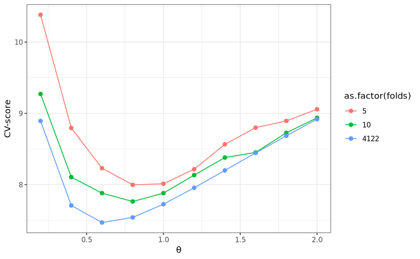